# Uso de Habitat de Tubarões Azul e Anequim no Oceano Atlântico Sul

Giulia Terlecki

1  
giuliaterlecki@gmail.com

Silvina Bota

2  
silvinabota@gmail.com

Luis Gustavo Cardoso

1  
luisgustavocardoso@gmail.com

# Abstract

Este estudo analisa o uso de habitat, a sobreposição de nicho e a conectividade do tubarão azul (*Prionace glauca*) e do anequim (*Isurus oxyrinchus*) no Atlântico Sul. Utilizando análises isotópicas e microquímicas em vértebras, investigamos mudanças ontogenéticas no uso de habitat e comportamentos alimentares dessas espécies. Os objetivos incluem avaliar a sobreposição de nicho, identificar especializações tróficas e verificar a conectividade do tubarão azul entre regiões do Atlântico Sul. Esperamos demonstrar uma sobreposição de nicho entre as espécies e evidências de conectividade transoceânica para o tubarão azul, fornecendo dados essenciais para manejo ecossistêmico e conservação.

keywords: - Conectividade - Sobreposição de nicho - Tubarão azul - Atlântico Sul - Análise isotópica - Ecologia trófica - Migração transoceânica - Gestão ecossistêmica

# Introduction

O tubarão azul (*Prionace glauca*) e o anequim (*Isurus oxyrinchus*) são duas das principais espécies de tubarões pelágicos do Atlântico, com distribuições amplas e migratórias que as tornam vulneráveis à exploração pesqueira [@Campana2004; @Stevens2010]. Essas espécies desempenham papéis ecológicos fundamentais nos ecossistemas marinhos, regulando as populações de suas presas e contribuindo para a manutenção do equilíbrio ecológico [@Heithaus2008]. Estudos recentes destacam a importância de compreender a conectividade populacional desses tubarões para desenvolver estratégias de manejo que considerem sua natureza transoceânica e evitem o declínio populacional [@Queiroz2019; @Ferreira2017].

O uso de análises isotópicas e microquímicas em vértebras de tubarões tem se mostrado uma ferramenta valiosa para rastrear padrões de migração, conectividade e mudanças ontogenéticas em hábitos alimentares [@Estrada2006; @Hussey2015]. Através dessas análises, é possível identificar as áreas de alimentação e os movimentos sazonais das espécies, fornecendo insights sobre as dinâmicas de habitat e as interações tróficas ao longo de diferentes fases da vida dos tubarões [@Carlisle2015; @MacNeil2005].

### Fórmula para Posição Trófica

Para estimar a posição trófica dos tubarões analisados, foi utilizada a seguinte fórmula de enriquecimento isotópico de nitrogênio entre predador e presa:

$$\Delta^{15}N = \delta^{15}N_{predador} - \delta^{15}N_{presa}$$

onde $\delta^{15}N$ representa o valor isotópico de nitrogênio nas amostras de vértebras, possibilitando inferir a posição trófica e os hábitos alimentares ontogenéticos dos indivíduos [@Shiffman2019; @Rooker2008].

Estudos como o de @Queiroz2019 demonstram que o tubarão azul exibe conectividade entre regiões do Atlântico, reforçando a necessidade de uma abordagem de manejo cooperativa entre diferentes países. Este estudo visa investigar a sobreposição de nicho entre o tubarão azul e o anequim no Atlântico Sul e avaliar a conectividade do tubarão azul entre as regiões sudoeste e sudeste do oceano.

# Results

Espera-se que os resultados deste estudo revelem uma sobreposição significativa de nicho entre o tubarão azul (*Prionace glauca*) e o anequim (*Isurus oxyrinchus*) no Atlântico Sul. A análise isotópica deverá indicar variações na posição trófica entre as fases ontogenéticas dos tubarões, evidenciando especializações alimentares em diferentes estágios de vida [@Carlisle2015; @Estrada2006].

### Sugestão de Imagem

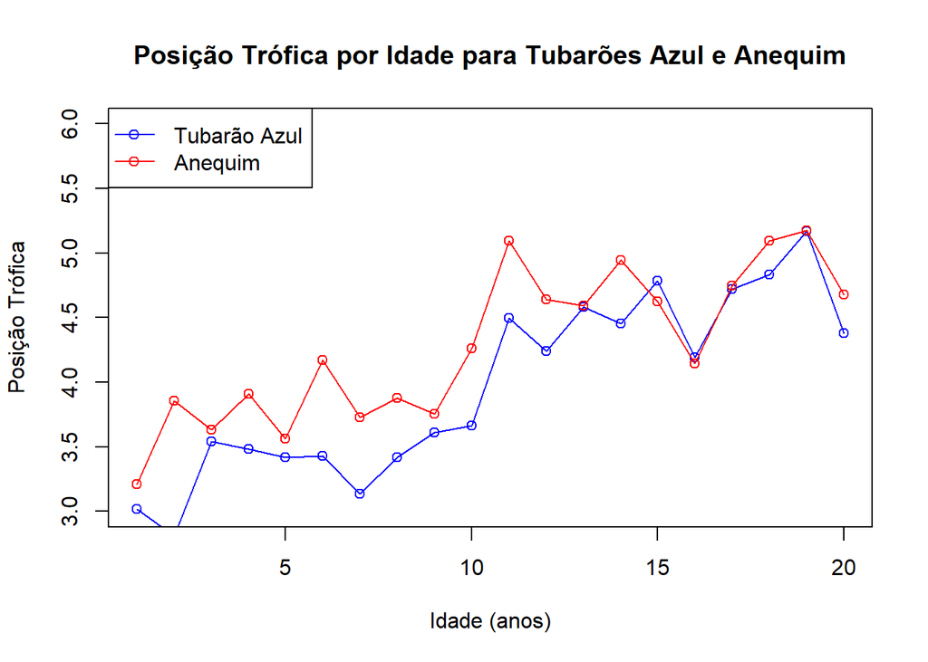

```r
# Simulação de dados
set.seed(999)
idades <- 1:20  # Classes etárias de 1 a 20 anos
trop_shark <- 3 + 0.1 * idades + rnorm(length(idades), sd = 0.3)  # Posição trófica simulada do tubarão azul
trop_mako <- 3.5 + 0.08 * idades + rnorm(length(idades), sd = 0.3)  # Posição trófica simulada do anequim

# Plotando o gráfico
plot(idades, trop_shark, type = "o", col = "blue", ylim = c(3, 6),
     main = "Posição Trófica por Idade para Tubarões Azul e Anequim",
     xlab = "Idade (anos)", ylab = "Posição Trófica")
lines(idades, trop_mako, type = "o", col = "red")
legend("topleft", legend = c("Tubarão Azul", "Anequim"), col = c("blue", "red"), lty = 1, pch = 1)
```